# analyze_example_data

## Example code to illustrate the API for cNMF on simulated data

- Current as of August 30 2018
- Email dkotliar@broadinstitute.org with questions

## Environment setup to run cNMF and this example:

- conda create -n cnmf_env python=3.6
- source activate cnmf_env
- conda install --yes --channel bioconda --channel conda-forge --channel defaults cython==0.28.2 fastcluster==1.1.24 jupyter==1.0.0 jupyterlab==0.32.1 matplotlib==2.2.2 numpy==1.12.1 palettable==3.1.1 pandas==0.23.0 scipy==1.1.0 && conda clean --yes --all
- pip install git+https://github.com/scikit-learn/scikit-learn.git@3b24a4855db8564ddccb011228c9f4a51a519c9a
- pip install --upgrade --no-cache-dir --upgrade-strategy=only-if-needed bhtsne==0.1.9 - only necessary if you want to generate the tsne output yourself

```python
%matplotlib inline
```

```python
import pandas as pd
import numpy as np
import matplotlib.pyplot as plt
from cnmf import cNMF, load_df_from_npz
```

## Download the example data from the web

```python
! wget -O ./example_data.tar.gz https://storage.googleapis.com/sabeti-public/dkotliar/cNMF/example_data_20180830.tar.gz
! tar -xzf ./example_data.tar.gz && rm ./example_data.tar.gz
```

## cNMF run parameters

```python
numiter=200
numworkers=6
numhvgenes=2000
run_name = 'example_cNMF'
K = ' '.join([str(i) for i in range(5,14)])
output_directory = './example_data'
countfn = './example_data/counts_prefiltered.txt'
seed = 14
```

## Prepare the normalized count matrix of highvar genes and the cNMF parameters file

```python
prepare_cmd = 'python ./cnmf.py prepare --output-dir %s --name %s -c %s -k %s --n-iter %d --total-workers %d --seed %d --numgenes %d' % (output_directory, run_name, countfn, K, numiter, numworkers, seed, numhvgenes)
print(prepare_cmd)
! {prepare_cmd}
```

```
python ./cnmf.py prepare --output-dir ./example_data --name example_cNMF -c ./example_data/counts_prefiltered.txt -k 5 6 7 8 9 10 11 12 13 --n-iter 200 --total-workers 6 --seed 14 --numgenes 2000
```

## Run replicates of cNMF for multiple K values in parallel

```python
## Using UGER
#logdir = './log'
#cmd = "qsub -cwd -b y -l h_vmem=2g,h_rt=3:00:00 -o %s -e %s -N cnmf -t 1-%d 'python ./cnmf.py factorize --output-dir %s --name %s --worker-index $SGE_TASK_ID'" % (logdir, logdir, nworkers, output_directory, run_name)

## Using GNU parallel
worker_index = ' '.join([str(x) for x in range(numworkers)])
cmd = 'nohup parallel python ./cnmf.py factorize --output-dir %s --name %s --worker-index {} ::: %s' % (output_directory, run_name, worker_index)
print(cmd)
!{cmd}
```

```
nohup parallel python ./cnmf.py factorize --output-dir ./example_data --name example_cNMF --worker-index {} ::: 0 1 2 3 4 5
nohup: ignoring input and appending output to 'nohup.out'
```

## Combine the replicate spectra into merged spectra files

```python
cmd = 'python ./cnmf.py combine --output-dir %s --name %s' % (output_directory, run_name)
print(cmd)
!{cmd}
```

```
python ./cnmf.py combine --output-dir ./example_data --name example_cNMF
Combining factorizations for k=5.
Combining factorizations for k=6.
Combining factorizations for k=7.
Combining factorizations for k=8.
Combining factorizations for k=9.
Combining factorizations for k=10.
Combining factorizations for k=11.
Combining factorizations for k=12.
Combining factorizations for k=13.
```

## Plot the trade-off between error and stability as a function of K to guide selection of K

```python
plot_K_selection_cmd = 'python ./cnmf.py k_selection_plot --output-dir %s --name %s' % (output_directory, run_name)
print(plot_K_selection_cmd)
!{plot_K_selection_cmd}
```

```
python ./cnmf.py k_selection_plot --output-dir ./example_data --name example_cNMF
```

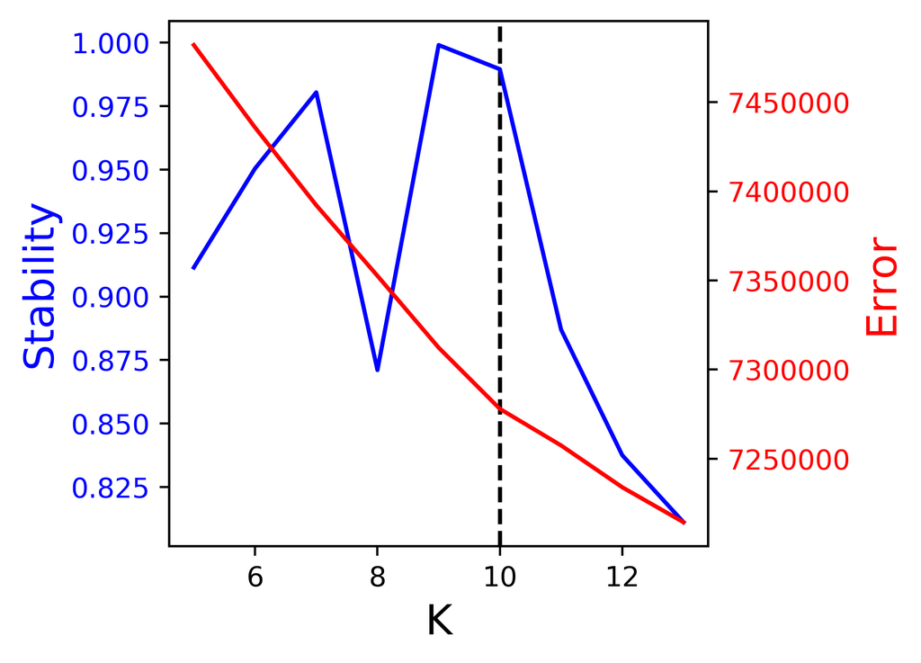

```python
### The plot was just saved to ./example_data/example_cNMF/example_cNMF.k_selection.pdf
### We also output it here in the notebook
def plot_comparison(stability, errors, ax1=None):
    '''
    'Make a plot to determine the choice of K. Plots stability in blue
    and error in red against K on the X axis of the same plot with different
    scales depicted on the left / right side Y-axis.
    '''
    if ax1 is None:
        (fig, ax1) = plt.subplots()
    ax2 = ax1.twinx()


    ax1.plot(stability.index, stability.values, color='b')
    ax1.set_ylabel('Stability', color='b', fontsize=15)
    for tl in ax1.get_yticklabels():
        tl.set_color('b')
    #ax1.set_xlabel('K', fontsize=15)

    ax2.plot(errors.index, errors.values, color='r')
    ax2.set_ylabel('Error', color='r', fontsize=15)
    for tl in ax2.get_yticklabels():
        tl.set_color('r')

    ax1.set_xlabel('Number of Components', fontsize=15)
    return(ax1, ax2)



Kselection_stats = load_df_from_npz('./example_data/example_cNMF/example_cNMF.k_selection_stats.df.npz')
Kselection_stats.index = Kselection_stats['k']
(fig,ax) = plt.subplots(1,1, figsize=(3.5,3.5), dpi=500)
(ax1, ax2) = plot_comparison(Kselection_stats['stability'], Kselection_stats['prediction_error'], ax1=ax)
ax1.set_ylabel('Stability', color='b', fontsize=15)
ax2.set_ylabel('Error', color='r', fontsize=15)
ax.set_xlabel('K', fontsize=15)
ylim = ax1.get_ylim()
ax1.vlines(x=10, ymin=ylim[0], ymax=ylim[1], linestyle='--')
_ = ax1.set_ylim(ylim)
```

### Based on the above plot, we would select K=10 as it is the K with the lowest error that has a very stable solution

## Obtain the consensus matrix factorization estimates

```python
## This is the command you would run from the command line to obtain the consensus estimate with no filtering
## and to save a diagnostic plot as a PDF
consensus_cmd = 'python ./cnmf.py consensus --output-dir %s --name %s --local-density-threshold %.2f' % (output_directory, run_name, 2.00)
print(consensus_cmd)
#!{consensus_cmd}
```

```
python ./cnmf.py consensus --output-dir ./example_data --name example_cNMF --local-density-threshold 2.00
```

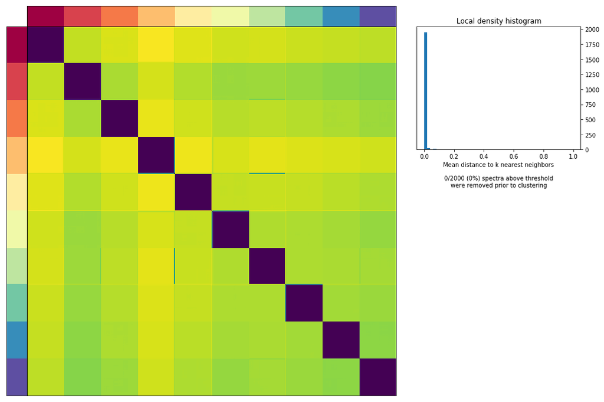

```python
## Instead of doing, we will run it in the notebook so that a nice embedded figure gets left here in
## addition to the other file outputs
cnmf_obj = cNMF(output_dir=output_directory, name=run_name)
cnmf_obj._initialize_dirs()
cnmf_obj.consensus(k=10, density_threshold_str='2.00', show_clustering = True, close_clustergram_fig=False)
```

based on the above diagnostic plots, we will filter all spectra with mean distance > .01 from their K nearest negighbors as below

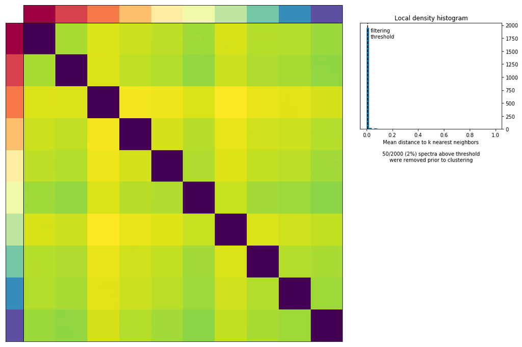

```python
cnmf_obj.consensus(k=10, density_threshold_str='0.01', show_clustering = True, close_clustergram_fig=False)
```

```python
! ls ./example_data/example_cNMF/
```

```
cnmf_tmp
example_cNMF.clustering.k_10.dt_0_01.pdf
example_cNMF.clustering.k_10.dt_2_00.pdf
example_cNMF.gene_spectra_score.k_10.dt_0_01.txt
example_cNMF.gene_spectra_score.k_10.dt_2_00.txt
example_cNMF.gene_spectra_tpm.k_10.dt_0_01.txt
example_cNMF.gene_spectra_tpm.k_10.dt_2_00.txt
example_cNMF.k_selection.pdf
example_cNMF.k_selection_stats.df.npz
example_cNMF.spectra.k_10.dt_0_01.consensus.txt
example_cNMF.spectra.k_10.dt_2_00.consensus.txt
example_cNMF.usages.k_10.dt_0_01.consensus.txt
example_cNMF.usages.k_10.dt_2_00.consensus.txt
```

### Our intended final results files are:

- example_cNMF.gene_spectra_score.k_10.dt_0_01.txt
- example_cNMF.gene_spectra_tpm.k_10.dt_0_01.txt
- example_cNMF.spectra.k_10.dt_0_01.consensus.txt
- example_cNMF.usages.k_10.dt_0_01.consensus.txt

## Make a few plots to illustrate the results

```python
from sklearn.decomposition import PCA
from sklearn import preprocessing
from bhtsne import tsne
```

### Run PCA on high-var genes TPM normalized

```python
spectra_hvgs = pd.read_csv('./example_data/example_cNMF/example_cNMF.spectra.k_10.dt_0_01.consensus.txt', sep='\t', index_col=0)
spectra_hvgs.head()

TPM = load_df_from_npz('./example_data/example_cNMF/cnmf_tmp/example_cNMF.tpm.df.npz') ## This is the TPM (transcripts per million normalized) file that was saved as an intermediate
TPM.head()

TPM_hvgs = TPM.loc[:, spectra_hvgs.columns] ## Subset only our list of highvar genes

## And run PCA
PCs = PCA(n_components=10).fit_transform(preprocessing.scale(TPM_hvgs))
PCs = pd.DataFrame(PCs, index=TPM_hvgs.index, columns=['PC%d' % i for i in range(1,11)])
PCs.head()
```

|  | PC1 | PC2 | PC3 | PC4 | PC5 | PC6 | PC7 | PC8 | PC9 | PC10 |
| --- | --- | --- | --- | --- | --- | --- | --- | --- | --- | --- |
| Cell1 | 0.403154 | -0.089489 | -0.265266 | 0.643520 | 0.561679 | 1.288522 | 3.335314 | -0.905429 | 0.859220 | -2.393386 |
| Cell2 | -4.153710 | 10.831701 | -2.634193 | -2.671814 | -2.408747 | -1.659478 | -0.086622 | 0.635833 | 0.432445 | -0.978888 |
| Cell3 | -0.188385 | -2.197751 | 3.886640 | -0.773563 | 1.464101 | 2.466530 | -0.729907 | 0.616986 | 1.830404 | -1.349871 |
| Cell4 | 6.085703 | -0.259023 | -0.393909 | 2.197336 | -2.982129 | -1.238465 | -1.140392 | 0.349985 | 7.503850 | 0.719213 |
| Cell5 | -0.132018 | -0.802674 | -0.866166 | 2.574302 | -3.253470 | 0.806679 | -0.945973 | -5.298993 | -2.855740 | 0.673271 |

### Run TSNE on PCs 1-10

```python
tsne_results = pd.DataFrame(tsne(PCs.values), index=PCs.index, columns=['TSNE1', 'TSNE2'])
tsne_results.to_csv('./example_data/tsne.txt', sep='\t')
```

### Plot the ground truth as well as the cNMF inferences on a tSNE plot

```python
usage_matrix = pd.read_csv('./example_data/example_cNMF/example_cNMF.usages.k_10.dt_0_01.consensus.txt', sep='\t', index_col=0)
usage_matrix.columns = np.arange(1,11)
normalized_usage_matrix = usage_matrix.div(usage_matrix.sum(axis=1), axis=0)
normalized_usage_matrix.head()
```

|  | 1 | 2 | 3 | 4 | 5 | 6 | 7 | 8 | 9 | 10 |
| --- | --- | --- | --- | --- | --- | --- | --- | --- | --- | --- |
| Cell1 | 0.117982 | 0.062424 | 0.088973 | 0.036176 | 0.069092 | 0.295651 | 0.117497 | 0.042182 | 0.000000 | 0.170021 |
| Cell2 | 0.000000 | 0.000000 | 0.046640 | 0.814974 | 0.057949 | 0.000000 | 0.000000 | 0.025809 | 0.054628 | 0.000000 |
| Cell3 | 0.047185 | 0.082994 | 0.132713 | 0.000000 | 0.000000 | 0.088277 | 0.085133 | 0.017616 | 0.256005 | 0.290076 |
| Cell4 | 0.000000 | 0.052069 | 0.460375 | 0.020727 | 0.076479 | 0.096262 | 0.266358 | 0.000000 | 0.000000 | 0.027730 |
| Cell5 | 0.476228 | 0.000000 | 0.119770 | 0.071296 | 0.079808 | 0.046883 | 0.018233 | 0.050729 | 0.025789 | 0.111265 |

```python
tsne_results = pd.read_csv('./example_data/tsne.txt', sep='\t', index_col=0)
tsne_results.head()
```

|  | TSNE1 | TSNE2 |
| --- | --- | --- |
| Cell1 | 9.697115 | 22.575700 |
| Cell2 | -36.028992 | 16.597681 |
| Cell3 | -20.461718 | -8.137485 |
| Cell4 | -9.772876 | 7.110056 |
| Cell5 | 7.802629 | 7.150789 |

```python
import palettable
from matplotlib import rcParams
from collections import Counter

rcParams['font.family'] = 'sans-serif'
rcParams['font.sans-serif'] = ['Myriad Pro']

rcParams['axes.titlesize'] = 9
rcParams['axes.labelsize'] = 9
rcParams['xtick.labelsize'] = 7
rcParams['ytick.labelsize'] = 7

rcParams['xtick.major.pad']='1'
rcParams['ytick.major.pad']='1'

import matplotlib as mpl
label_size = 8

core_colors = type('CoreColors', (), {})

cnames = ['red', 'blue', 'green', 'purple', 'orange', 'yellow', 'brown', 'pink', 'grey']

def to_array_col(color):
    return np.array(color)/255.

for cname,c in zip(cnames, palettable.colorbrewer.qualitative.Set1_9.colors):
    setattr(core_colors, cname, np.array(c)/255.)

for cname, c in zip(['blue', 'green', 'red', 'orange', 'purple'],
                    palettable.colorbrewer.qualitative.Paired_10.colors[::2]):
    setattr(core_colors, 'pale_'+cname, np.array(c)/255.)

core_colors.teal = to_array_col(palettable.colorbrewer.qualitative.Set2_3.colors[0])
core_colors.brown_red = to_array_col(palettable.colorbrewer.qualitative.Dark2_3.colors[1])

# core_colors.light_grey = to_array_col(palettable.colorbrewer.qualitative.Set2_8.colors[-1])
core_colors.light_grey = to_array_col(palettable.tableau.TableauLight_10.colors[7])

core_colors.royal_green = to_array_col(palettable.wesanderson.Royal1_4.colors[0])
```

```python
celldata = pd.read_csv('./example_data/groundtruth_cellparams.txt', sep='\t', index_col=0)
celldata.head()
```

|  | group | libsize | has_program | program_usage | is_doublet | group2 |
| --- | --- | --- | --- | --- | --- | --- |
| Cell1 | 5 | 1630.218732 | False | 0.000000 | False | -1 |
| Cell2 | 7 | 2705.729416 | False | 0.000000 | False | -1 |
| Cell3 | 8 | 1128.292000 | False | 0.000000 | True | 9 |
| Cell4 | 1 | 4000.648864 | True | 0.601523 | False | -1 |
| Cell5 | 3 | 3286.997845 | False | 0.000000 | False | -1 |

```python
tsnedat = pd.merge(left=tsne_results, right=celldata, left_index=True, right_index=True)

tsnedat['extra-status'] = 'Normal'
tsnedat.loc[tsnedat['has_program'] & ~tsnedat['is_doublet'], 'extra-status'] = 'program'
tsnedat.loc[~tsnedat['has_program'] & tsnedat['is_doublet'], 'extra-status'] = 'doublet'
tsnedat.loc[ tsnedat['has_program'] & tsnedat['is_doublet'], 'extra-status'] = 'program & doublet'
```

```python
cell_tableau10_color_id = tsnedat['group'].astype(int).values - 1
cell_tableau10_color = np.array(palettable.tableau.Tableau_10.colors[:-1])[cell_tableau10_color_id]/255.

activity_color = np.zeros((tsnedat.shape[0], 4))
activity_color[:, 3] = tsnedat['has_program'].astype(float)
doublet_color = np.array(palettable.tableau.TableauMedium_10.colors[5])/255.
```

```python
normal_filter = tsnedat['extra-status'] == 'Normal'
doublet_filter = tsnedat['extra-status'] == 'doublet'
activity_filter = tsnedat['extra-status'] == 'program'
activity_and_doublet_filter = tsnedat['extra-status'] == 'program & doublet'
```

[output not shown]

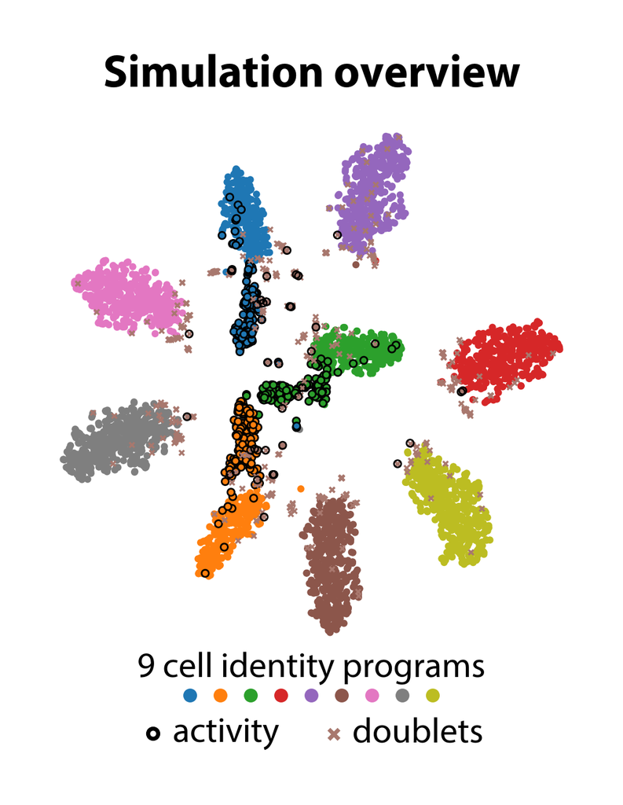

```python
import matplotlib.gridspec as gridspec

fig = plt.figure(figsize=(1.5, 2), dpi=600)
gs = gridspec.GridSpec(3, 1, fig, 0,0,1,1,
                       hspace=0, wspace=0,
                       height_ratios=[0.2, 1.5, 0.3],
                       width_ratios=[1])

ax = fig.add_subplot(gs[1, 0],
          xscale='linear', yscale='linear',
          frameon=False, xticks=[], yticks=[])

x = tsnedat['TSNE1']
y = tsnedat['TSNE2']


curr_filter = normal_filter


ax.scatter(x[curr_filter], y[curr_filter],
          facecolor=cell_tableau10_color[curr_filter.values],
           edgecolor='none',
           rasterized=True, s=2)

curr_filter = activity_filter
ax.scatter(x[curr_filter], y[curr_filter],
          facecolor=cell_tableau10_color[curr_filter.values],
          edgecolor=activity_color[curr_filter.values], linewidth=0.33,
           rasterized=False, s=2)


curr_filter = doublet_filter | activity_and_doublet_filter
ax.scatter(x[curr_filter], y[curr_filter],
          c=doublet_color,
          edgecolor='none', marker='x', linewidth=0.4,
          s=1)

curr_filter = activity_and_doublet_filter
ax.scatter(x[curr_filter], y[curr_filter],
          facecolor='none',
          edgecolor=activity_color[curr_filter.values], linewidth=0.33,
           rasterized=False, s=2)


ax = fig.add_subplot(gs[0, 0],
          frameon=False, xticks=[], yticks=[], xlim=[0,1], ylim=[0,1])

ax.text(0.50, 0.5, 'Simulation overview', va='center', ha='center', fontsize=9, fontdict=dict(weight='bold'),
        clip_on=False)


ax = fig.add_subplot(gs[2, 0],
          frameon=False, xticks=[], yticks=[], xlim=[0,1], ylim=[0,1])

ax.text(0.50, 0.9, '9 cell identity programs', va='center', ha='center', fontsize=7,
        clip_on=False)

leg_x = np.arange(9)/18
leg_x -= leg_x.mean()
leg_x += 0.5

ax.scatter(leg_x, np.ones(9)*0.65, c=np.array(palettable.tableau.Tableau_10.colors[:-1])/255, s=3)



activity_y = 0.30
ax.text(0.33, activity_y, '  activity', verticalalignment='center', ha='center', fontsize=7,
        clip_on=False)

ax.scatter([0.21], [activity_y],
           facecolor='none', edgecolor='k', linewidth=0.8, s=4)


doub_y = activity_y
ax.text(0.66, doub_y, '     doublets', verticalalignment='center', ha='center', fontsize=7,
        clip_on=False)

ax.scatter([0.54], [doub_y], c=[doublet_color],
           edgecolor='none', marker='x', linewidth=0.8, s=4, clip_on=False)

ax.set_xlim([0,1])
ax.set_ylim([0,1])
```

```python
tsne_and_usages = pd.merge(left=normalized_usage_matrix, right=tsne_results, left_index=True, right_index=True)
tsne_and_usages.head()
```

|  | 1 | 2 | 3 | 4 | 5 | 6 | 7 | 8 | 9 | 10 | TSNE1 | TSNE2 |
| --- | --- | --- | --- | --- | --- | --- | --- | --- | --- | --- | --- | --- |
| Cell1 | 0.117982 | 0.062424 | 0.088973 | 0.036176 | 0.069092 | 0.295651 | 0.117497 | 0.042182 | 0.000000 | 0.170021 | 9.697115 | 22.575700 |
| Cell2 | 0.000000 | 0.000000 | 0.046640 | 0.814974 | 0.057949 | 0.000000 | 0.000000 | 0.025809 | 0.054628 | 0.000000 | -36.028992 | 16.597681 |
| Cell3 | 0.047185 | 0.082994 | 0.132713 | 0.000000 | 0.000000 | 0.088277 | 0.085133 | 0.017616 | 0.256005 | 0.290076 | -20.461718 | -8.137485 |
| Cell4 | 0.000000 | 0.052069 | 0.460375 | 0.020727 | 0.076479 | 0.096262 | 0.266358 | 0.000000 | 0.000000 | 0.027730 | -9.772876 | 7.110056 |
| Cell5 | 0.476228 | 0.000000 | 0.119770 | 0.071296 | 0.079808 | 0.046883 | 0.018233 | 0.050729 | 0.025789 | 0.111265 | 7.802629 | 7.150789 |

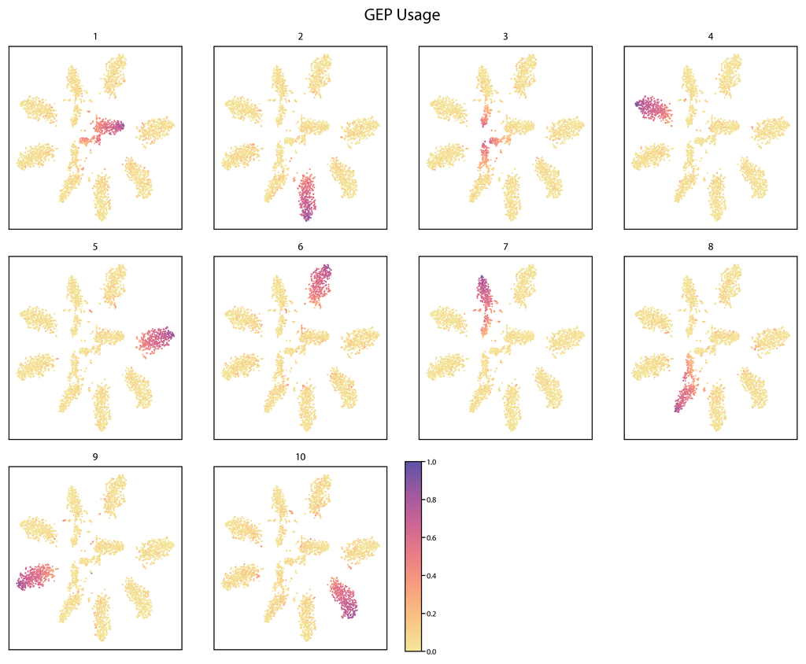

```python
cmap = palettable.cartocolors.sequential.Sunset_7.get_mpl_colormap()

(fig,axes) = plt.subplots(3,4, figsize=(10,8), dpi=400)
axes = axes.ravel()
for i in range(1, 11):
    sc = axes[i-1].scatter(tsne_and_usages['TSNE1'], tsne_and_usages['TSNE2'], c=tsne_and_usages[i],
                      cmap=cmap, vmin=0, vmax=1.,
                      s=2, edgecolor='none', rasterized=True)
    axes[i-1].set_title(i)
    axes[i-1].set_xticks([])
    axes[i-1].set_yticks([])



plt.tight_layout()
fig.delaxes(axes[11])
fig.delaxes(axes[10])
cbarax = fig.add_axes([.5,0.035,.02, .29])
plt.colorbar(sc, cax=cbarax)
_ = plt.figtext(.45,1,'GEP Usage', fontsize=15)
```